# Group Project - Predicting Insurance Price

STAT 420, Summer 2019 - Bingxue An (bingxue3); Vivian Hu (vivianh2); Andong Jing (ajing2)

August 3rd, 2019

## Introduction

### Background

The Medical Cost Personal Datasets is a dataset provided by Brett Lantz (2015) in his book *Machine Learning with R*. The data was made available on [Kaggle](https://www.kaggle.com/) for public analysis by Miri Choi (2018).

### Links and Citation

The dataset (“`insurance.csv`”) is available on [Kaggle](https://www.kaggle.com/). It can be downloaded by going to [Medical Cost Personal Datasets](https://www.kaggle.com/mirichoi0218/insurance) page.

Citation:

- Lantz, B. (2015). Machine learning with R. Packt Publishing Ltd.
- Choi, M. (2018). Medical Cost Personal Datasets.

### Description of the Dataset Variables

- `Charges`: Individual medical costs billed by health insurance (numeric) - **response**
- `Sex`: Insurance contractor gender: (factor)
  - `female`
  - `male`
- `Region`: The beneficiary’s residential area in the US: (factor)
  - `northeast`
  - `southeast`
  - `northwest`
  - `southwest`
- `Smoker`: The beneficiary’s smoking status: (factor)
  - `yes`
  - `no`
- `bmi`: Body mass index, providing an understanding of body, weights that are relatively high or low relative to height, objective index of body weight (kg / m ^ 2) using the ratio of height to weight, ideally 18.5 to 24.9 (numeric)
- `children`: Number of children covered by health insurance / Number of dependents (numeric)
- `age`: Age of primary beneficiary

Here are the first 5 observations of the dataset:

```r
insuranceData = read.csv("insurance.csv")
head(insuranceData, 5)
```

```
##   age    sex   bmi children smoker    region charges
## 1  19 female 27.90        0    yes southwest   16885
## 2  18   male 33.77        1     no southeast    1726
## 3  28   male 33.00        3     no southeast    4449
## 4  33   male 22.70        0     no northwest   21984
## 5  32   male 28.88        0     no northwest    3867
```

### Statement of Interest

Once upon a time, insurance agents were like local doctors - they need to know individuals and communities inside-out to give the right price. However, To match that level of knowledge in the age of decentralization and the internet, the insurance industry is turning to big data. All of the members in our group are very interested in dealing with the data in healthcare area and hope that we can develop a great model to predict insurance costs accurately.

### Model

In this project, a multiple linear regression model will be developed by selecting the best of them from several different models. The model will be used in making predictions about the insurance prices using rest of the variables.

### Goal

By applying data analysis technique on insurance data, our goal is to help the agents to give the right price to the customers more accurately and hope that we can develop a great model to predict insurance costs accurately.

## Methods

### Exploratory Data Analysis

To better develop our model, we would like to have an overall view of the dataset and a visualization of the dataset would be performed.

```r
summary(insuranceData)
```

```
##       age           sex           bmi          children    smoker
##  Min.   :18.0   female:662   Min.   :16.0   Min.   :0.00   no :1064
##  1st Qu.:27.0   male  :676   1st Qu.:26.3   1st Qu.:0.00   yes: 274
##  Median :39.0                Median :30.4   Median :1.00
##  Mean   :39.2                Mean   :30.7   Mean   :1.09
##  3rd Qu.:51.0                3rd Qu.:34.7   3rd Qu.:2.00
##  Max.   :64.0                Max.   :53.1   Max.   :5.00
##        region       charges
##  northeast:324   Min.   : 1122
##  northwest:325   1st Qu.: 4740
##  southeast:364   Median : 9382
##  southwest:325   Mean   :13270
##                  3rd Qu.:16640
##                  Max.   :63770
```

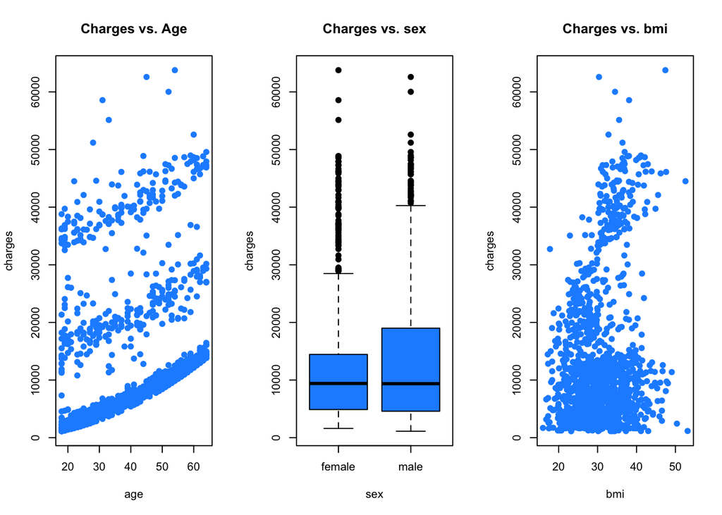

```r
par(mfrow = c(1,3))
plot(charges ~ age, data = insuranceData, pch = 20, col = "dodgerblue",main = "Charges vs. Age", cex = 1.5)
plot(charges ~ sex, data = insuranceData, pch = 20, col = "dodgerblue",main = "Charges vs. sex", cex = 1.5)
plot(charges ~ bmi, data = insuranceData, pch = 20, col = "dodgerblue",main = "Charges vs. bmi", cex = 1.5)
```

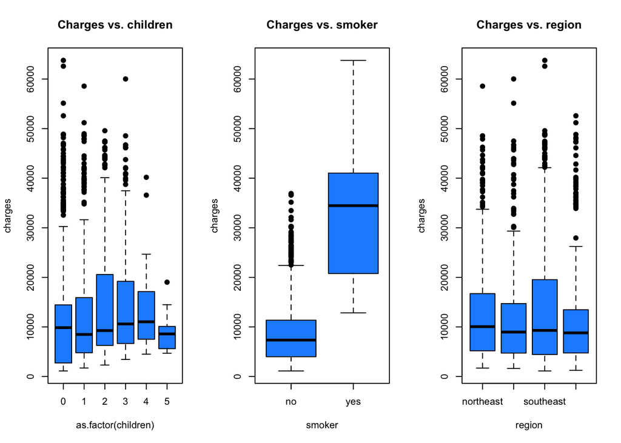

```r
par(mfrow = c(1,3))
plot(charges ~ as.factor(children), data = insuranceData, pch = 20, col = "dodgerblue",main = "Charges vs. children", cex = 1.5)
plot(charges ~ smoker, data = insuranceData, pch = 20, col = "dodgerblue",main = "Charges vs. smoker", cex = 1.5)
plot(charges ~ region, data = insuranceData, pch = 20, col = "dodgerblue",main = "Charges vs. region", cex = 1.5)
```

As we can see, there’s an obvious linear relationship between age and the charges, where charges increase as the `age` increases. We can also observe that there are three groups of lines visible. While `females` and `males` pay the same charges on average, the relationship with `bmi` is not that clear. The variable `smoker` would also be very useful since the subject who are smokers are charged much more than those who are not smokers. The relationship between charge and the number of `children` as well as the relationship between charge and `region` are less obvious. Most importantly, it is worth noticing that the distributions are skewed.

### Data Preprocessing

Before we start developing the model, we need to clean the data.

```r
# We want to remove all those rows with missing data
insuranceData = na.omit(insuranceData)
# We would like to consider sex,smoker and region as factor variable
if(is.factor(insuranceData$sex)==FALSE)
  insuranceData$sex = as.factor(insuranceData$sex)
if(is.factor(insuranceData$smoker)==FALSE)
  insuranceData$smoker = as.factor(insuranceData$smoker)
if(is.factor(insuranceData$region)==FALSE)
  insuranceData$region = as.factor(insuranceData$region)
```

### Split Train and Test Data

In order to test how well our models work, we would like to splot the data into `train` and `test` sets, and develop the models on `train` while test our models on `test`.

```r
# 80% of the data will be used for training and the rest for testing
set.seed(420)
trainIndex = sample(1:nrow(insuranceData),round(nrow(insuranceData) * 0.80, 0))
trainSet = insuranceData[trainIndex,]
testSet = insuranceData[-trainIndex,]
```

### Helper functions

Before we start to build our model, we want to define some helper functions to make our job easier.

```r
calc_loocv_rmse = function(model) {
  sqrt(mean((resid(model) / (1 - hatvalues(model))) ^ 2))
}

aic = function(model){
  step(model, direction = "backward",trace = 0)
}

bic = function(model){
  step(model, direction = "backward", trace = 0, k = log(length(resid(model))))
}

# output results in a table
table = function(aic, bic) {
  results = data.frame(
    method = c("`AIC model`", "`BIC model`"),
    loocv  = c(get_loocv_rmse(aic), get_loocv_rmse(bic)),
    params = c(length(coef(aic)), length(coef(bic)))
  )
  colnames(results) = c("", "LOOCV", "Number of Parameters")
  knitr::kable(results)
}

#This function calculates the RMSE of a dataset.
RMSE = function( model, data = NULL){
  if (is.null(data)){
    return (sqrt(mean((model$residuals)^2 )))
  }
  predict_val = predict(model, newdata = data)
  return(sqrt(mean((data$charges - predict_val) ^ 2)))
}
```

### Model Building

#### Additive Model

First we start with a full additive model as a baseline.

```r
full_additive = lm(charges~., data = trainSet)
summary(full_additive)
```

```
##
## Call:
## lm(formula = charges ~ ., data = trainSet)
##
## Residuals:
##    Min     1Q Median     3Q    Max
## -11250  -2838   -978   1310  30173
##
## Coefficients:
##                 Estimate Std. Error t value Pr(>|t|)
## (Intercept)     -12081.0     1117.0  -10.82   <2e-16 ***
## age                252.2       13.5   18.68   <2e-16 ***
## sexmale            102.9      376.4    0.27   0.7847
## bmi                341.8       32.3   10.58   <2e-16 ***
## children           460.6      155.6    2.96   0.0031 **
## smokeryes        23785.1      467.0   50.94   <2e-16 ***
## regionnorthwest    208.4      539.7    0.39   0.6995
## regionsoutheast  -1112.9      544.0   -2.05   0.0410 *
## regionsouthwest   -917.1      541.6   -1.69   0.0907 .
## ---
## Signif. codes:  0 '***' 0.001 '**' 0.01 '*' 0.05 '.' 0.1 ' ' 1
##
## Residual standard error: 6120 on 1061 degrees of freedom
## Multiple R-squared:  0.745,  Adjusted R-squared:  0.743
## F-statistic:  386 on 8 and 1061 DF,  p-value: <2e-16
```

Then, we do the BP test and the shapiro test for this model. We find that the p-values for both tests are very close to zero, and thus, the constant variance assumption and the normality assumption for this model are violated.

```r
library(lmtest)
bptest(full_additive)$p.value
```

```
##        BP
## 2.057e-18
```

```r
shapiro.test(resid(full_additive))$p.value
```

```
## [1] 2.447e-26
```

The following observations are those we believe influential (have Cook’s Distance is greater than 4/n, where n is the total number of observations).

```r
(num_influential = sum(cooks.distance(full_additive) > 4 / length(cooks.distance(full_additive))))
```

```
## [1] 64
```

```r
full_add_influential_table = knitr::kable(insuranceData[cooks.distance(full_additive) > 4 / length(cooks.distance(full_additive)),])
head(full_add_influential_table, 10)
```

```
##  [1] "        age  sex         bmi   children  smoker   region       charges"
##  [2] "-----  ----  -------  ------  ---------  -------  ----------  --------"
##  [3] "35       28  male      36.40          1  yes      southwest      51195"
##  [4] "51       18  female    35.62          0  no       northeast       2211"
##  [5] "58       18  male      31.68          2  yes      southeast      34303"
##  [6] "68       40  male      26.32          1  no       northwest       6389"
##  [7] "129      32  female    17.77          2  yes      northwest      32734"
##  [8] "135      20  female    28.79          0  no       northeast       2457"
##  [9] "137      19  male      34.10          0  no       southwest       1261"
## [10] "148      51  female    37.73          1  no       southeast       9878"
```

```r
cooksD = cooks.distance(full_additive)
full_additive_2 = lm(charges~., data = trainSet, subset = cooksD <= 4 / length(cooksD))

results = data.frame(coef(full_additive), coef(full_additive_2))
colnames(results) = c("With Influential Pts", "Without Influential Pts")
knitr::kable(results)
```

|  | With Influential Pts | Without Influential Pts |
| --- | --- | --- |
| (Intercept) | -12081.0 | -11930.6 |
| age | 252.2 | 247.1 |
| sexmale | 102.9 | 232.6 |
| bmi | 341.8 | 316.3 |
| children | 460.6 | 514.4 |
| smokeryes | 23785.1 | 24492.2 |
| regionnorthwest | 208.4 | -340.1 |
| regionsoutheast | -1112.9 | -1254.4 |
| regionsouthwest | -917.1 | -840.1 |

From the table above, we can see that most of the coefficients are influenced by the influential points, in some way but not significantly. However there are some coefficients, such as `sex:male` and `region:northwest` are significantly affected by these influential points.

#### Interaction Model

First we start with a full interaction model as a baseline.

```r
full_interaction = lm(charges~.^2, data = trainSet)
summary(full_interaction)
```

```
##
## Call:
## lm(formula = charges ~ .^2, data = trainSet)
##
## Residuals:
##    Min     1Q Median     3Q    Max
## -10597  -1987  -1217   -161  30265
##
## Coefficients:
##                            Estimate Std. Error t value Pr(>|t|)
## (Intercept)                -1731.87    2906.39   -0.60  0.55138
## age                          209.37      59.76    3.50  0.00048 ***
## sexmale                    -1824.86    1774.27   -1.03  0.30395
## bmi                           22.29      93.99    0.24  0.81256
## children                    1207.88     770.23    1.57  0.11714
## smokeryes                 -22415.49    2172.00  -10.32  < 2e-16 ***
## regionnorthwest            -1095.43    2548.90   -0.43  0.66746
## regionsoutheast             2845.24    2455.08    1.16  0.24676
## regionsouthwest              475.00    2440.58    0.19  0.84572
## age:sexmale                   28.56      21.63    1.32  0.18695
## age:bmi                        1.15       1.83    0.63  0.52990
## age:children                  -9.27       9.77   -0.95  0.34295
## age:smokeryes                 -4.61      26.95   -0.17  0.86407
## age:regionnorthwest           -3.44      30.83   -0.11  0.91112
## age:regionsoutheast           24.07      31.17    0.77  0.44012
## age:regionsouthwest           18.13      31.80    0.57  0.56867
## sexmale:bmi                    6.58      52.06    0.13  0.89950
## sexmale:children            -122.51     250.97   -0.49  0.62556
## sexmale:smokeryes           -400.90     763.54   -0.53  0.59966
## sexmale:regionnorthwest      304.00     859.07    0.35  0.72351
## sexmale:regionsoutheast      905.24     865.74    1.05  0.29598
## sexmale:regionsouthwest      192.75     865.76    0.22  0.82386
## bmi:children                  -1.06      21.95   -0.05  0.96164
## bmi:smokeryes               1556.79      63.84   24.39  < 2e-16 ***
## bmi:regionnorthwest           23.60      77.93    0.30  0.76208
## bmi:regionsoutheast         -154.63      68.53   -2.26  0.02424 *
## bmi:regionsouthwest          -70.93      75.85   -0.94  0.34996
## children:smokeryes          -412.83     316.33   -1.31  0.19216
## children:regionnorthwest     220.23     364.79    0.60  0.54615
## children:regionsoutheast    -352.02     366.97   -0.96  0.33765
## children:regionsouthwest    -571.00     350.55   -1.63  0.10365
## smokeryes:regionnorthwest   -669.40    1094.65   -0.61  0.54099
## smokeryes:regionsoutheast  -1650.58    1037.97   -1.59  0.11210
## smokeryes:regionsouthwest    992.52    1109.34    0.89  0.37116
## ---
## Signif. codes:  0 '***' 0.001 '**' 0.01 '*' 0.05 '.' 0.1 ' ' 1
##
## Residual standard error: 4830 on 1036 degrees of freedom
## Multiple R-squared:  0.845,  Adjusted R-squared:  0.84
## F-statistic:  171 on 33 and 1036 DF,  p-value: <2e-16
```

Then, we do the BP test and the shapiro test for this model. We find that the p-value for BP test is very large; much greater than 0.1. Thus, the constant variance assumption for this model is NOT violated. However, the shapiro test has a p-value very close to 0. Thus, the normality assumption for this model is violated.

```r
bptest(full_interaction)$p.value
```

```
##     BP
## 0.7676
```

```r
shapiro.test(resid(full_interaction))$p.value
```

```
## [1] 7.915e-41
```

```r
(num_influential = sum(cooks.distance(full_interaction) > 4 / length(cooks.distance(full_interaction))))
```

```
## [1] 78
```

```r
full_inter_influential_table = knitr::kable(trainSet[cooks.distance(full_interaction) > 4 / length(cooks.distance(full_interaction)),])
head(full_inter_influential_table, 10)
```

```
##  [1] "        age  sex         bmi   children  smoker   region       charges"
##  [2] "-----  ----  -------  ------  ---------  -------  ----------  --------"
##  [3] "293      25  male      45.54          2  yes      southeast      42112"
##  [4] "1157     19  male      44.88          0  yes      southeast      39723"
##  [5] "960      48  male      36.67          1  no       northwest      28469"
##  [6] "40       60  male      39.90          0  yes      southwest      48173"
##  [7] "1329     23  female    24.23          2  no       northeast      22396"
##  [8] "251      18  male      17.29          2  yes      northeast      12829"
##  [9] "504      19  male      30.25          0  yes      southeast      32548"
## [10] "1302     62  male      30.88          3  yes      northwest      46718"
```

We perform variable selection using backwards AIC. The resulting model is denoted as `interaction_aic`

```r
n = length(resid(full_interaction))
interaction_aic = step(full_interaction, direction = "backward", trace = 0)
```

We perform ANOVA test for `interaction_aic` model and `full_interaction` model. We find that the p-value is 0.7163 > 0.1, thus we prefer the `interaction_aic` model.

```r
anova(interaction_aic,full_interaction)
```

```
## Analysis of Variance Table
##
## Model 1: charges ~ age + bmi + children + smoker + region + bmi:smoker +
##     bmi:region + children:region
## Model 2: charges ~ (age + sex + bmi + children + smoker + region)^2
##   Res.Df      RSS Df Sum of Sq    F Pr(>F)
## 1   1055 2.45e+10
## 2   1036 2.42e+10 19 352312956 0.79   0.72
```

#### Polynomial Model

First we start with a model containing the first and second order of every variable.

```r
full_polynomial = lm(charges~ . +I(age^2) +I(bmi^2) +I(children^2), data = trainSet)
summary(full_polynomial)
```

```
##
## Call:
## lm(formula = charges ~ . + I(age^2) + I(bmi^2) + I(children^2),
##     data = trainSet)
##
## Residuals:
##    Min     1Q Median     3Q    Max
## -10755  -3146  -1258   1665  30695
##
## Coefficients:
##                  Estimate Std. Error t value Pr(>|t|)
## (Intercept)     -16258.51    3965.73   -4.10 0.000045 ***
## age                -57.11      93.40   -0.61  0.54107
## sexmale             68.30     374.06    0.18  0.85516
## bmi                967.75     236.07    4.10 0.000045 ***
## children           960.67     416.19    2.31  0.02118 *
## smokeryes        23767.26     464.04   51.22  < 2e-16 ***
## regionnorthwest     56.65     537.75    0.11  0.91611
## regionsoutheast  -1090.10     540.51   -2.02  0.04397 *
## regionsouthwest   -980.28     539.04   -1.82  0.06926 .
## I(age^2)             3.87       1.16    3.32  0.00092 ***
## I(bmi^2)           -10.01       3.72   -2.69  0.00724 **
## I(children^2)     -104.60     112.82   -0.93  0.35409
## ---
## Signif. codes:  0 '***' 0.001 '**' 0.01 '*' 0.05 '.' 0.1 ' ' 1
##
## Residual standard error: 6080 on 1058 degrees of freedom
## Multiple R-squared:  0.749,  Adjusted R-squared:  0.746
## F-statistic:  287 on 11 and 1058 DF,  p-value: <2e-16
```

Then, we perform the BP test and the shapiro test for this model. We find that the p-values for both tests are very close to zero, and thus, the constant variance assumption and the normality assumption for this model are violated.

```r
bptest(full_polynomial)$p.value
```

```
##        BP
## 2.453e-17
```

```r
shapiro.test(resid(full_polynomial))$p.value
```

```
## [1] 4.944e-27
```

```r
(num_influential = sum(cooks.distance(full_polynomial) > 4 / length(cooks.distance(full_polynomial))))
```

```
## [1] 59
```

```r
full_poly_influential_table = knitr::kable(trainSet[cooks.distance(full_polynomial) > 4 / length(cooks.distance(full_polynomial)),])
head(full_poly_influential_table, 10)
```

```
##  [1] "        age  sex         bmi   children  smoker   region       charges"
##  [2] "-----  ----  -------  ------  ---------  -------  ----------  --------"
##  [3] "293      25  male      45.54          2  yes      southeast      42112"
##  [4] "1157     19  male      44.88          0  yes      southeast      39723"
##  [5] "960      48  male      36.67          1  no       northwest      28469"
##  [6] "1329     23  female    24.23          2  no       northeast      22396"
##  [7] "381      27  female    17.95          2  yes      northeast      15007"
##  [8] "251      18  male      17.29          2  yes      northeast      12829"
##  [9] "877      49  female    27.10          1  no       southwest      26140"
## [10] "1028     23  male      18.71          0  no       northwest      21595"
```

#### Combined Model

```r
#add an additional column, which will be used for combined model, explanations will be provided later
trainSet$bmi30 = ifelse(trainSet$bmi >= 30, "yes", "no")
combined_model = lm(charges ~ age + I(age^2) + children + bmi + sex + bmi30:smoker + region, data=trainSet)
summary(combined_model)
```

```
##
## Call:
## lm(formula = charges ~ age + I(age^2) + children + bmi + sex +
##     bmi30:smoker + region, data = trainSet)
##
## Residuals:
##    Min     1Q Median     3Q    Max
## -17338  -1714  -1213   -605  24414
##
## Coefficients: (1 not defined because of singularities)
##                      Estimate Std. Error t value Pr(>|t|)
## (Intercept)         31269.186   1806.756   17.31  < 2e-16 ***
## age                    -4.486     67.617   -0.07  0.94711
## I(age^2)                3.358      0.843    3.99  7.2e-05 ***
## children              632.772    118.429    5.34  1.1e-07 ***
## bmi                   138.512     38.547    3.59  0.00034 ***
## sexmale              -363.366    274.941   -1.32  0.18658
## regionnorthwest       -28.306    393.655   -0.07  0.94269
## regionsoutheast     -1018.494    397.372   -2.56  0.01051 *
## regionsouthwest     -1315.136    395.104   -3.33  0.00090 ***
## bmi30no:smokerno   -31987.364    594.770  -53.78  < 2e-16 ***
## bmi30yes:smokerno  -33354.130    469.094  -71.10  < 2e-16 ***
## bmi30no:smokeryes  -18883.469    715.659  -26.39  < 2e-16 ***
## bmi30yes:smokeryes         NA         NA      NA       NA
## ---
## Signif. codes:  0 '***' 0.001 '**' 0.01 '*' 0.05 '.' 0.1 ' ' 1
##
## Residual standard error: 4460 on 1058 degrees of freedom
## Multiple R-squared:  0.865,  Adjusted R-squared:  0.863
## F-statistic:  614 on 11 and 1058 DF,  p-value: <2e-16
```

Then, we perform the BP test and the shapiro test for this model. We find that the p-values for shapiro test is very close to zero, and thus, the normality assumption for this model are violated.

```r
bptest(combined_model)$p.value
```

```
##     BP
## 0.6836
```

```r
shapiro.test(resid(combined_model))$p.value
```

```
## [1] 6.802e-48
```

## Result

```r
anova(full_additive, interaction_aic)
```

```
## Analysis of Variance Table
##
## Model 1: charges ~ age + sex + bmi + children + smoker + region
## Model 2: charges ~ age + bmi + children + smoker + region + bmi:smoker +
##     bmi:region + children:region
##   Res.Df      RSS Df Sum of Sq   F Pr(>F)
## 1   1061 3.98e+10
## 2   1055 2.45e+10  6  1.52e+10 109 <2e-16 ***
## ---
## Signif. codes:  0 '***' 0.001 '**' 0.01 '*' 0.05 '.' 0.1 ' ' 1
```

```r
anova(full_polynomial, interaction_aic)
```

```
## Analysis of Variance Table
##
## Model 1: charges ~ age + sex + bmi + children + smoker + region + I(age^2) +
##     I(bmi^2) + I(children^2)
## Model 2: charges ~ age + bmi + children + smoker + region + bmi:smoker +
##     bmi:region + children:region
##   Res.Df      RSS Df Sum of Sq   F Pr(>F)
## 1   1058 3.91e+10
## 2   1055 2.45e+10  3  1.46e+10 209 <2e-16 ***
## ---
## Signif. codes:  0 '***' 0.001 '**' 0.01 '*' 0.05 '.' 0.1 ' ' 1
```

```r
RMSE_trn = c(RMSE(full_additive), RMSE(interaction_aic), RMSE(full_polynomial), RMSE(combined_model))
testSet_combined = testSet
testSet_combined$bmi30 = ifelse(testSet_combined$bmi >= 30, "yes", "no")
RMSE_test = c(RMSE(full_additive, testSet), RMSE(interaction_aic, testSet), RMSE(full_polynomial, testSet), RMSE(combined_model, testSet_combined))
knitr::kable(data.frame(variable = c("additive", "interactive", "polynomial", "combined"), RMSE_trn, RMSE_test))
```

| variable | RMSE_trn | RMSE_test |
| --- | --- | --- |
| additive | 6099 | 5843 |
| interactive | 4790 | 4912 |
| polynomial | 6047 | 5797 |
| combined | 4440 | 4394 |

```r
knitr::kable(data.frame(model = c("additive", "interactive", "polynomial", "combined"), "adjusted R squared" = c(summary(full_additive)$"adj.r.squared", summary(interaction_aic)$"adj.r.squared", summary(full_polynomial)$"adj.r.squared", summary(combined_model)$"adj.r.squared")))
```

| model | adjusted.R.squared |
| --- | --- |
| additive | 0.7426 |
| interactive | 0.8403 |
| polynomial | 0.7462 |
| combined | 0.8632 |

## Discussion

For the first full_additivee model, we only utilized those given variables included in the dataset and actually got a relatively good r-squared of 0.743, which indicates that 74.3% of the variation of charges could be explained by the variables we have included. We could also observe most of the variables we included are statistically significant predictors for medical charges.

For the full interactive model, we only consider the interactions between two variables for simplicity. After performing variable selection using AIC, there are three interactive terms in `interaction_aic` model. Compared with the all additive model and the polynomial model, its adjusted $R^2$ is increased by 0.1 and the RMSE is decreased by 1000. Thus we know that the best model contains some interaction terms. The way to increase the accuracy may be considering the higher order terms of variables.